# Assignment 10

## Try to submit as an HTML file

Print your name below

```python
print("Sigrid Matthews")
```

```
Sigrid Matthews
```

Import the "pandas" and "matplotlib.pyplot" libraries.

```python
# Write your answer here:

import pandas as pd
import matplotlib.pyplot as plt
```

In this assignment, we will work with a World Bank  
dataset on the proportion of urban population across  
countries, from 2016-2020.

- This is an example of a "panel"/"longitudinal" dataset

which contains information about the same unit (country)  
over time.

- This is in "long" format (see Lecture 22)

(a) Import data and parse dates

- Import "data_raw/wdi_long.csv"
- Create a new column called "date" which uses `pd.to_datetime(...,format = ...)`

to convert year to a date format

- To get full points use wild cards to establish the format.

Hint: See Lecture 21 for information about wild cards

```python
# Write your own code
wdi_long = pd.read_csv("data_raw/wdi_long.csv")
wdi_long["date"] = pd.to_datetime(wdi_long["year"], format = "%Y")
display(wdi_long)
```

|  | year | year_code | country_name | country_code | prop_urban | date |
| --- | --- | --- | --- | --- | --- | --- |
| 0 | 2016 | YR2016 | Afghanistan | AFG | 25.020 | 2016-01-01 |
| 1 | 2016 | YR2016 | Albania | ALB | 58.421 | 2016-01-01 |
| 2 | 2016 | YR2016 | Algeria | DZA | 71.459 | 2016-01-01 |
| 3 | 2016 | YR2016 | American Samoa | ASM | 87.198 | 2016-01-01 |
| 4 | 2016 | YR2016 | Andorra | AND | 88.248 | 2016-01-01 |
| ... | ... | ... | ... | ... | ... | ... |
| 1080 | 2020 | YR2020 | Virgin Islands (U.S.) | VIR | 95.939 | 2020-01-01 |
| 1081 | 2020 | YR2020 | West Bank and Gaza | PSE | 76.719 | 2020-01-01 |
| 1082 | 2020 | YR2020 | Yemen, Rep. | YEM | 37.908 | 2020-01-01 |
| 1083 | 2020 | YR2020 | Zambia | ZMB | 44.629 | 2020-01-01 |
| 1084 | 2020 | YR2020 | Zimbabwe | ZWE | 32.242 | 2020-01-01 |

1085 rows × 6 columns

(b) Sort by two columns

- Create a new dataset "data_sorted" that sorts by "country_name" and "date"

HINT: Include a list of column names as the main sorting argument.

```python
# Write your own code
data_sorted = wdi_long.sort_values(["country_name", "date"],ascending = True)
display(data_sorted)
```

|  | year | year_code | country_name | country_code | prop_urban | date |
| --- | --- | --- | --- | --- | --- | --- |
| 0 | 2016 | YR2016 | Afghanistan | AFG | 25.020 | 2016-01-01 |
| 217 | 2017 | YR2017 | Afghanistan | AFG | 25.250 | 2017-01-01 |
| 434 | 2018 | YR2018 | Afghanistan | AFG | 25.495 | 2018-01-01 |
| 651 | 2019 | YR2019 | Afghanistan | AFG | 25.754 | 2019-01-01 |
| 868 | 2020 | YR2020 | Afghanistan | AFG | 26.026 | 2020-01-01 |
| ... | ... | ... | ... | ... | ... | ... |
| 216 | 2016 | YR2016 | Zimbabwe | ZWE | 32.296 | 2016-01-01 |
| 433 | 2017 | YR2017 | Zimbabwe | ZWE | 32.237 | 2017-01-01 |
| 650 | 2018 | YR2018 | Zimbabwe | ZWE | 32.209 | 2018-01-01 |
| 867 | 2019 | YR2019 | Zimbabwe | ZWE | 32.210 | 2019-01-01 |
| 1084 | 2020 | YR2020 | Zimbabwe | ZWE | 32.242 | 2020-01-01 |

1085 rows × 6 columns

(c) Compute grouped time differences

**Example**

- Each country has data for multiple dates
- The following code calculates the time-difference between each date

```
(data_sorted.groupby("country_name")["date"]
            .diff())
```

**Instructions**:

- Now, instead of ["date"] use `["prop_urban"]`
- Store the result in a new column called "diff_prop_urban"
- This adds a new column with the country-level changes in

the urban propulaton each year

HINT: Check Lecture 22 for using `.diff()`  
Note: Using ".groupby()" is important so that each country is analyzed  
separately.

```python
# Write your own code

data_sorted["diff_prop_urban"] = (data_sorted.groupby("country_name")["prop_urban"]
            .diff())
display(data_sorted)
```

|  | year | year_code | country_name | country_code | prop_urban | date | diff_prop_urban |
| --- | --- | --- | --- | --- | --- | --- | --- |
| 0 | 2016 | YR2016 | Afghanistan | AFG | 25.020 | 2016-01-01 | NaN |
| 217 | 2017 | YR2017 | Afghanistan | AFG | 25.250 | 2017-01-01 | 0.230 |
| 434 | 2018 | YR2018 | Afghanistan | AFG | 25.495 | 2018-01-01 | 0.245 |
| 651 | 2019 | YR2019 | Afghanistan | AFG | 25.754 | 2019-01-01 | 0.259 |
| 868 | 2020 | YR2020 | Afghanistan | AFG | 26.026 | 2020-01-01 | 0.272 |
| ... | ... | ... | ... | ... | ... | ... | ... |
| 216 | 2016 | YR2016 | Zimbabwe | ZWE | 32.296 | 2016-01-01 | NaN |
| 433 | 2017 | YR2017 | Zimbabwe | ZWE | 32.237 | 2017-01-01 | -0.059 |
| 650 | 2018 | YR2018 | Zimbabwe | ZWE | 32.209 | 2018-01-01 | -0.028 |
| 867 | 2019 | YR2019 | Zimbabwe | ZWE | 32.210 | 2019-01-01 | 0.001 |
| 1084 | 2020 | YR2020 | Zimbabwe | ZWE | 32.242 | 2020-01-01 | 0.032 |

1085 rows × 7 columns

(d) Plot time series for single country

- Use ".query()" to subset "data_sorted" for rows that satisfy

$\quad$ `'country_name == "United States"'`

- Produce a line plot with the evolution of "prop_urban" over time in the

United States

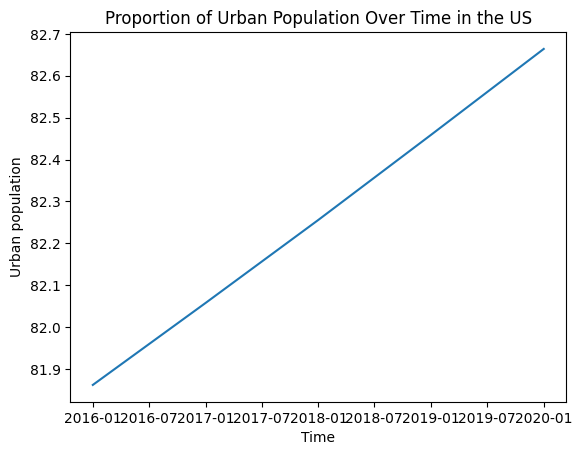

```python
# Write your own code
sorted_us = data_sorted.query('country_name == "United States"')
plt.plot("date","prop_urban",
          data = sorted_us.sort_values("date",ascending = True))
plt.xlabel("Time")
plt.ylabel("Urban population")
plt.title("Proportion of Urban Population Over Time in the US")
```

(e) Convert to wide format

- Convert "data_sorted" from long to wide, using the following arguments:

```
   index = 'country_name'
   columns = 'year'
   values =  'prop_urban'
```

- Display the dataset to check that it is in wide format

HINT: See Lecture 22 for details

```python
# Write your own code
data_wide = (pd.pivot(data_sorted,
                           index = 'country_name',
                           columns = 'year',
                           values =  'prop_urban'))

data_wide
```

| year country_name | 2016 | 2017 | 2018 | 2019 | 2020 |
| --- | --- | --- | --- | --- | --- |
| Afghanistan | 25.020 | 25.250 | 25.495 | 25.754 | 26.026 |
| Albania | 58.421 | 59.383 | 60.319 | 61.229 | 62.112 |
| Algeria | 71.459 | 72.052 | 72.629 | 73.189 | 73.733 |
| American Samoa | 87.198 | 87.170 | 87.153 | 87.147 | 87.153 |
| Andorra | 88.248 | 88.150 | 88.062 | 87.984 | 87.916 |
| ... | ... | ... | ... | ... | ... |
| Virgin Islands (U.S.) | 95.480 | 95.603 | 95.721 | 95.832 | 95.939 |
| West Bank and Gaza | 75.628 | 75.894 | 76.164 | 76.440 | 76.719 |
| Yemen, Rep. | 35.394 | 36.016 | 36.642 | 37.273 | 37.908 |
| Zambia | 42.438 | 42.976 | 43.521 | 44.072 | 44.629 |
| Zimbabwe | 32.296 | 32.237 | 32.209 | 32.210 | 32.242 |

217 rows × 5 columns